# Statistical Computing HW1

110024516 統研碩一 邱繼賢

## (1) Weibull distribution

$$\begin{aligned}
&X\ \sim\ F(x)\ =\ 1-e^{-(\frac{x}{\theta})^\beta}\ \ ,\ \theta > 0\ ,\ \beta>0\ ,\ x>0\\
&\Rightarrow\ F^{-1}(p)\ =\ \theta[-log(1-p)]^{\frac{1}{\beta}}\\
&\text{Let}\ \ U\ \sim\ U(0,1)\ ,\ \text{and}\ \because\ F(X)\ \stackrel{d}{=}\ U\ \sim\ U(0,1)\\
&\therefore\ X\ \stackrel{d}{=}\ F^{-1}(U)\ =\ \theta[-log(1-U)]^{\frac{1}{\beta}}\ \sim\ F\\
\end{aligned}$$

Therefore, we can draw 1000 samples from the *U(0,1)* distribution, and transform the samples by the inverse cdf to represent the original distribution (namely Weibull distribution).

Take $(\theta\ ,\ \beta)\ =\ (1,5)$ for example. The results are shown as below :

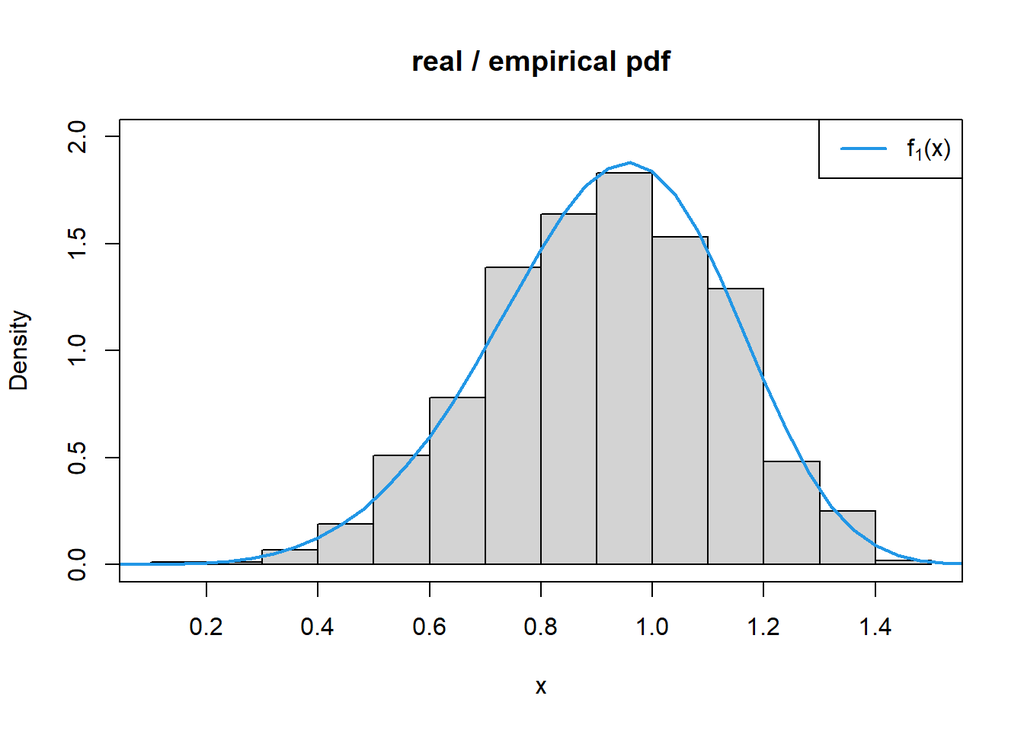

## (2) Pareto distribution

$$\begin{aligned}
&\text{Target pdf : }\ f_2(x\ ;\ \theta,\beta)\ =\ \frac{\beta}{\theta(1+\frac{x}{\theta})^{\beta+1}}\ ,\ \theta>0\ ,\ \beta>0\ ,\ x>0\\
&\text{Proposal pdf : }\ g_2(x\ ;\ \nu)\ =\ 2\ h(x\ ;\ \nu)\ ,\ x>0\ ,\ \nu>0\ ,\\
&\text{where}\ h(x\ ;\ \nu)\ \text{is the pdf of t distribution with degree of freedom}\ =\ \nu\\
&\text{Compute the value}\ M_2\ \text{, such that}\ M_2\ \geq\ Max_{x>0}\frac{f_2(x\ ;\ \theta,\beta)}{g_2(x\ ;\ \nu)}\\
&\text{Generate}\ Y\ \sim\ g_2\ \text{and}\ U\ \sim\ U(0,1)\ \text{.}\\
&\text{Let}\ X=Y\ \text{if}\ U\ \leq\ \frac{f_2(Y)}{M_2\ g_2(Y)}\ \text{, and reject the draw otherwise.}\\
&\text{Hence, the theoretical efficiency :}\ P(U\ \leq\ \frac{f_2(Y)}{M_2\ g_2(Y)})\ =\ \frac{1}{M_2}
\end{aligned}$$

Take $(\theta\ ,\ \beta\ ,\ \nu)\ =\ (15\ ,\ 10\ ,\ 1)$ for example, and find a sufficient large $M_2\ =\ 1.411$ s.t. the theoretical efficiency $=\ \frac{1}{M_2}\ \approx\ 70.87\%$. The results are shown as below :

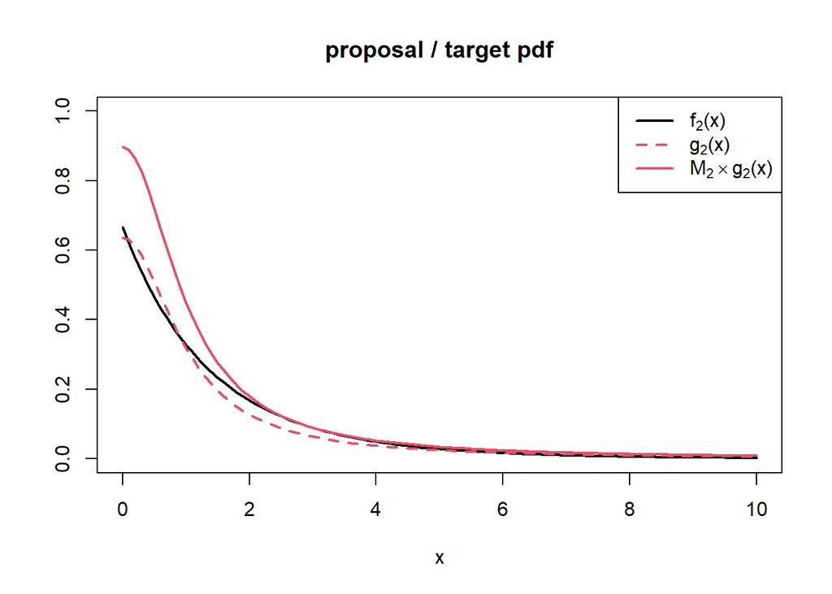

Draw 1000 samples separately from $g_2$ and $U(0,1)$, and follow the rejection rule as above to construct our target pdf $f_2(x)$. The results are shown as below :

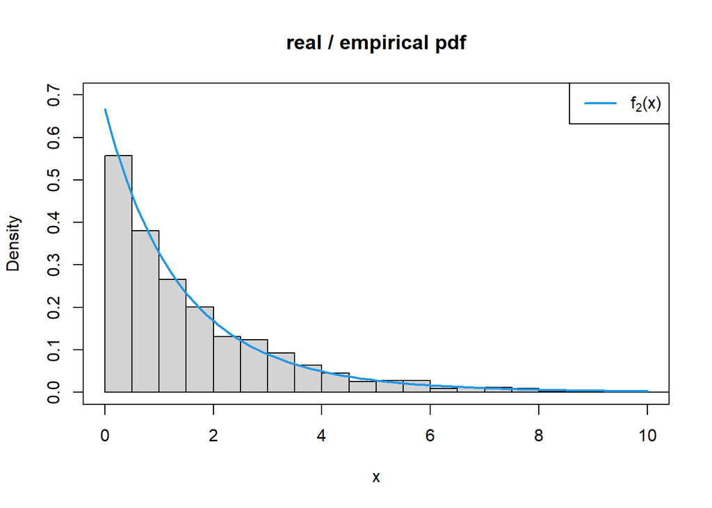

Finally, compute the empirical efficiency $=\ 71.5\%$

## (3) Skewed distribution I

$$\begin{aligned}
&\text{Target pdf : }\ f_3(x\ ;\ \gamma)\ =\ \frac{2}{\gamma+\frac{1}{\gamma}}\ \phi(x\gamma^{-sign(x)})\ ,\ x\in R\ ,\ \gamma\ >\ 0\\
&\text{Proposal pdf : }\ g_3(x\ ;\ \mu,\sigma^2)\ \sim\ N(\mu\ ,\ \sigma^2)\ \ ,\ x\ \in\ R\ ,\ \mu\in R\ ,\ \sigma^2>0\\
&\text{Compute the value}\ M_3\ \text{, such that}\ M_3\ \geq\ Max_{x\in R}\frac{f_3(x\ ;\ \gamma)}{g_3(x\ ;\ \mu,\sigma^2)}\\
&\text{Generate}\ Y\ \sim\ g_3\ \text{and}\ U\ \sim\ U(0,1)\ \text{.}\\
&\text{Let}\ X=Y\ \text{if}\ U\ \leq\ \frac{f_3(Y)}{M_3\ g_3(Y)}\ \text{, and reject the draw otherwise.}\\
&\text{Hence, the theoretical efficiency :}\ P(U\ \leq\ \frac{f_3(Y)}{M_3\ g_3(Y)})\ =\ \frac{1}{M_3}
\end{aligned}$$

[figure not shown]

Draw 1000 samples separately from $g_3$ and $U(0,1)$, and follow the rejection rule as above to construct our target pdf $f_3(x)$. The results are shown as below :

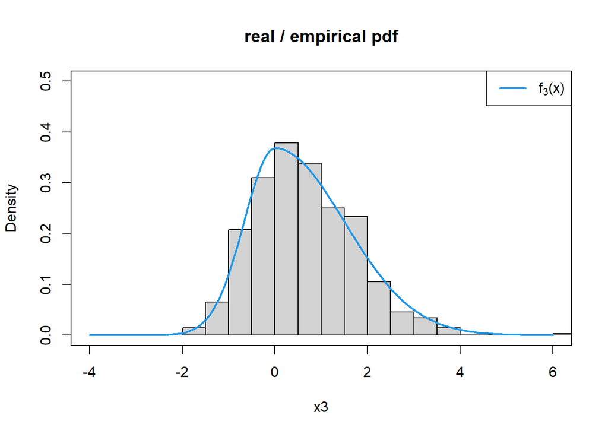

Finally, compute the empirical efficiency $=\ 70.3\%$

## (4) Skewed distribution II

### (a)

$$\begin{aligned}
&\text{Target pdf : }\ f_{4.1}(x\ ;\ \alpha,\nu_1)\ =\ 2h(x\ ;\ \nu_1)\ G(\alpha x\ ;\ \nu_1)\ ,\ x\in R\ ,\ \alpha\in R\ ,\ \nu_1>0\\
&\text{where}\ h(x)\ \text{and}\ G(x)\ \text{are the pdf and cdf of t distribution with}\ \nu_1\ \text{degree of freedom}\\
&\text{Proposal pdf : }\ g_{4.1}(x\ ;\ \nu_2)\ \sim\ t(\nu_2)\ \ ,\ x\ \in\ R\ ,\ \nu_2>0\\
&\text{Compute the value}\ M_{4.1}\ \text{, such that}\ M_{4.1}\ \geq\ Max_{x\in R}\frac{f_{4.1}(x\ ;\ \alpha,\nu_1)}{g_{4.1}(x\ ;\ \nu_2)}\\
&\text{Generate}\ Y\ \sim\ g_{4.1}\ \text{and}\ U\ \sim\ U(0,1)\ \text{.}\\
&\text{Let}\ X=Y\ \text{if}\ U\ \leq\ \frac{f_{4.1}(Y)}{M_{4.1}\ g_{4.1}(Y)}\ \text{, and reject the draw otherwise.}\\
&\text{Hence, the theoretical efficiency :}\ P(U\ \leq\ \frac{f_{4.1}(Y)}{M_{4.1}\ g_{4.1}(Y)})\ =\ \frac{1}{M_{4.1}}
\end{aligned}$$

Take $(\alpha\ ,\ \nu_1\ ,\ \nu_2)\ =\ (1\ ,\ 2\ ,\ 1)$ for example, and find a sufficient large $M_{4.1}\ =\ 2.015$ s.t. the theoretical efficiency $=\ \frac{1}{M_{4.1}}\ \approx\ 49.63\%$. The results are shown as below :

[figure not shown]

Draw 1000 samples separately from $g_{4.1}$ and $U(0,1)$, and follow the rejection rule as above to construct our target pdf $f_{4.1}(x)$. The results are shown as below :

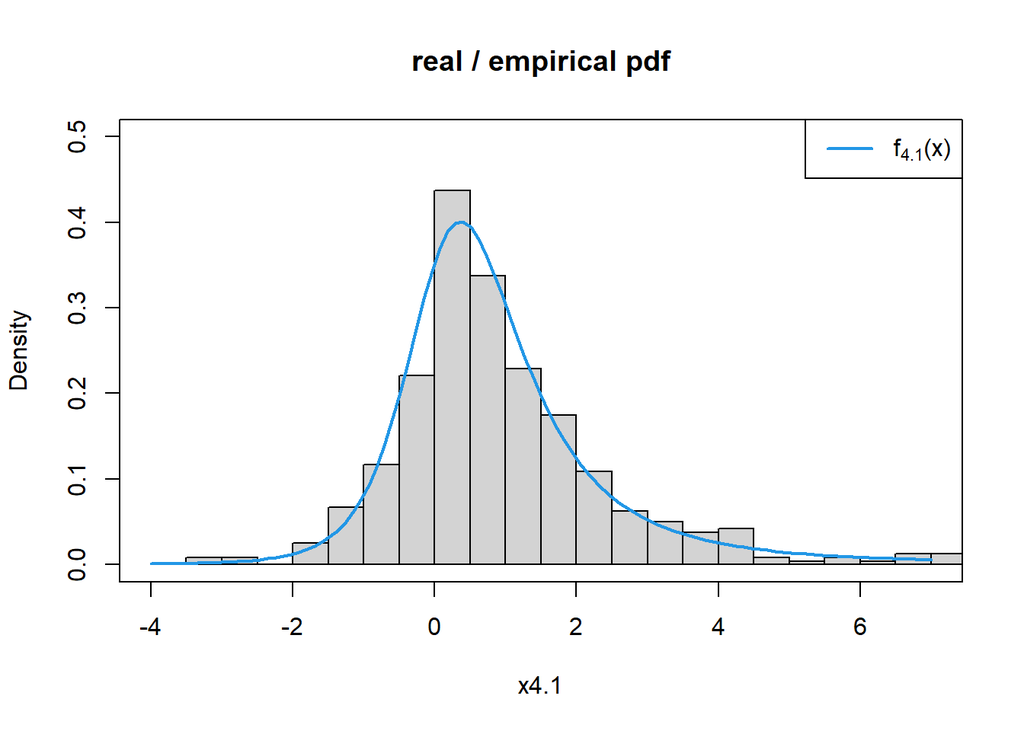

Finally, compute the empirical efficiency $=\ 48\%$

### (b)

Now I decided to construct the skewed-double-exponential distribution, then $G(x)$ and $h(x)$ are the cdf and pdf of double-exponential distribution. Later, I will use both methods in Problems (3) and (4).

$$\begin{aligned}
&\textbf{Method 1.}\\
&h(x\ ;\ \lambda)\ =\ \frac{1}{2}\lambda e^{-\lambda|x|}\ ,\ x\in R\ ,\ \lambda>0\\
&G(x\ ;\ \lambda)\ =\ \int_{-\infty}^x h(u\ ;\ \lambda)\ du\ =\ \frac{1}{2}[1+sign(x)(1-e^{-\lambda|x|})]\ ,\ x\in R\ ,\ \lambda>0\\
&\text{By method in Problem (3), define}\\
&\text{Target pdf :}\ f_{4.2.1}(x\ ;\ \lambda,\gamma)\ =\ \frac{2}{\gamma+\frac{1}{\gamma}}\ h(x\gamma^{-sign(x)}\ ;\ \lambda)\ ,\ x\in R\ ,\ \lambda>0\ ,\ \gamma>0\\
&\text{Proposal pdf : }\ g_{4.2.1}(x\ ;\ \nu)\ \sim\ t(\nu)\ \ ,\ x\ \in\ R\ ,\ \nu>0\\
&\text{Compute the value}\ M_{4.2.1}\ \text{, such that}\ M_{4.2.1}\ \geq\ Max_{x\in R}\frac{f_{4.2.1}(x\ ;\ \lambda,\gamma)}{g_{4.2.1}(x\ ;\ \nu)}\\
&\text{Generate}\ Y\ \sim\ g_{4.2.1}\ \text{and}\ U\ \sim\ U(0,1)\ \text{.}\\
&\text{Let}\ X=Y\ \text{if}\ U\ \leq\ \frac{f_{4.2.1}(Y)}{M_{4.2.1}\ g_{4.2.1}(Y)}\ \text{, and reject the draw otherwise.}\\
&\text{Hence, the theoretical efficiency :}\ P(U\ \leq\ \frac{f_{4.2.1}(Y)}{M_{4.2.1}\ g_{4.2.1}(Y)})\ =\ \frac{1}{M_{4.2.1}}
\end{aligned}$$

Take $(\lambda\ ,\ \gamma\ ,\ \nu)\ =\ (1\ ,\ 1.5\ ,\ 1)$ for example, and find a sufficient large $M_{4.2.1}\ =\ 1.989$ s.t. the theoretical efficiency $=\ \frac{1}{M_{4.2.1}}\ \approx\ 50.28\%$. The results are shown as below :

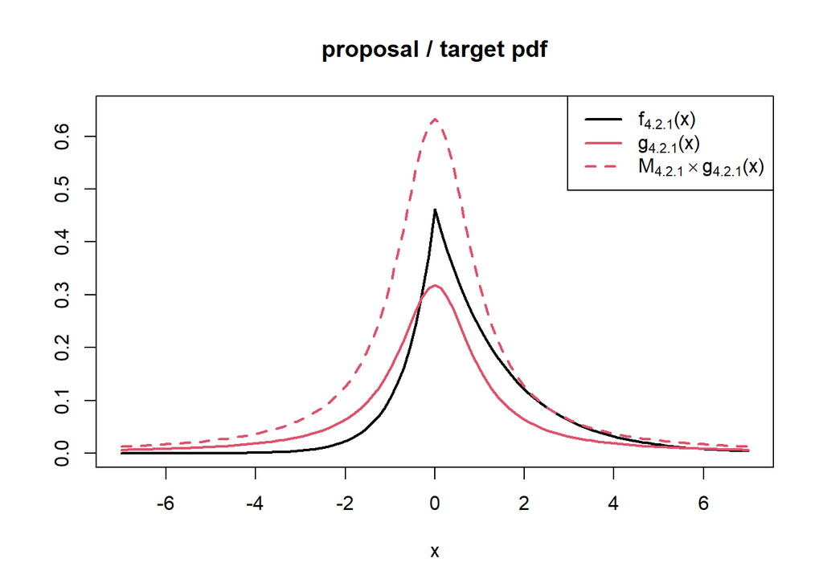

Draw 1000 samples separately from $g_{4.2.1}$ and $U(0,1)$, and follow the rejection rule as above to construct our target pdf $f_{4.2.1}(x)$. The results are shown as below :

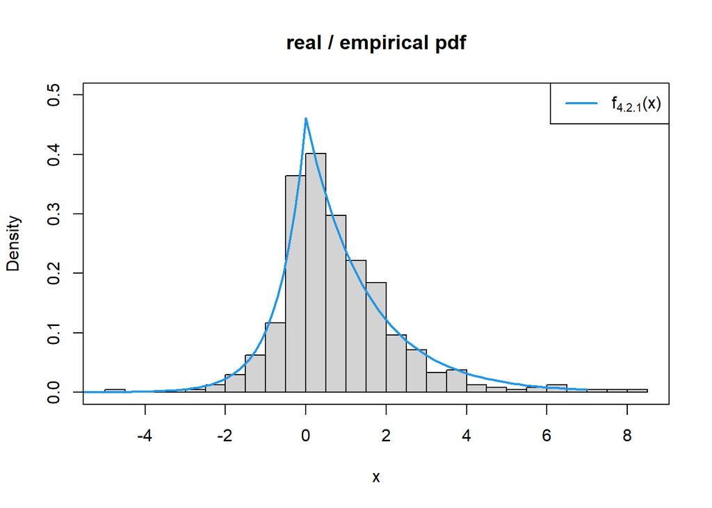

Finally, compute the empirical efficiency $=\ 47.8\%$

$$\begin{aligned}
&\textbf{Method 2.}\\
&\text{By method in Problem (4), define}\\
&\text{Target pdf :}\ f_{4.2.2}(x\ ;\ \lambda,\alpha)\ =\ 2h(x\ ;\ \lambda)G(\alpha x\ ;\ \lambda)\ ,\ x\in R\ ,\ \lambda>0\ ,\ \alpha\in R\\
&\text{Proposal pdf : }\ g_{4.2.2}(x\ ;\ \nu)\ \sim\ t(\nu)\ \ ,\ x\ \in\ R\ ,\ \nu>0\\
&\text{Compute the value}\ M_{4.2.2}\ \text{, such that}\ M_{4.2.2}\ \geq\ Max_{x\in R}\frac{f_{4.2.2}(x\ ;\ \lambda,\alpha)}{g_{4.2.2}(x\ ;\ \nu)}\\
&\text{Generate}\ Y\ \sim\ g_{4.2.2}\ \text{and}\ U\ \sim\ U(0,1)\ \text{.}\\
&\text{Let}\ X=Y\ \text{if}\ U\ \leq\ \frac{f_{4.2.2}(Y)}{M_{4.2.2}\ g_{4.2.2}(Y)}\ \text{, and reject the draw otherwise.}\\
&\text{Hence, the theoretical efficiency :}\ P(U\ \leq\ \frac{f_{4.2.2}(Y)}{M_{4.2.2}\ g_{4.2.2}(Y)})\ =\ \frac{1}{M_{4.2.2}}
\end{aligned}$$

Take $(\lambda\ ,\ \alpha\ ,\ \nu)\ =\ (1\ ,\ 0.5\ ,\ 1)$ for example, and find a sufficient large $M_{4.2.2}\ =\ 1.756$ s.t. the theoretical efficiency $=\ \frac{1}{M_{4.2.2}}\ \approx\ 56.95\%$. The results are shown as below :

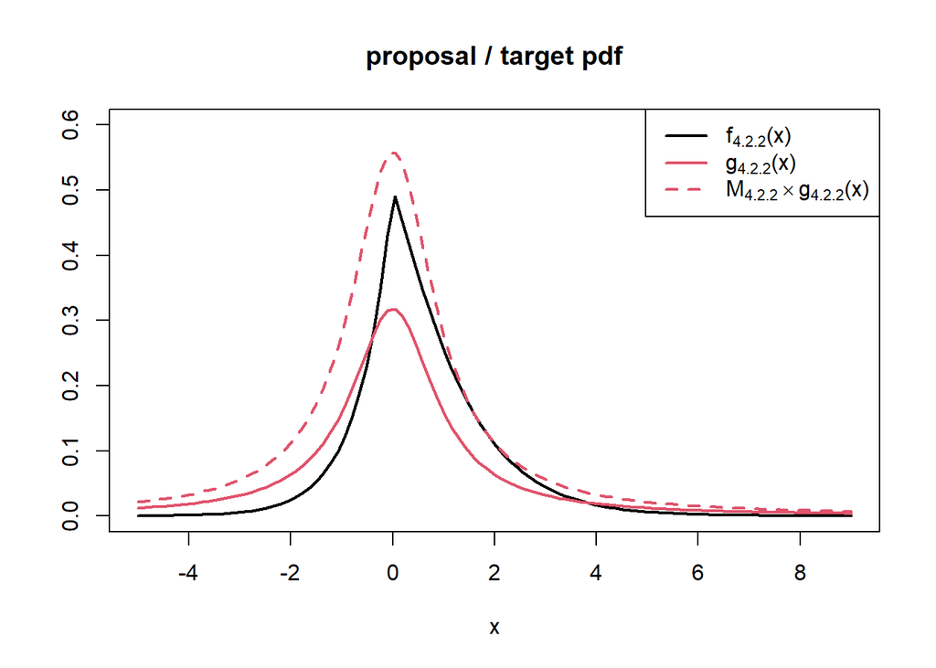

Draw 1000 samples separately from $g_{4.2.2}$ and $U(0,1)$, and follow the rejection rule as above to construct our target pdf $f_{4.2.2}(x)$. The results are shown as below :

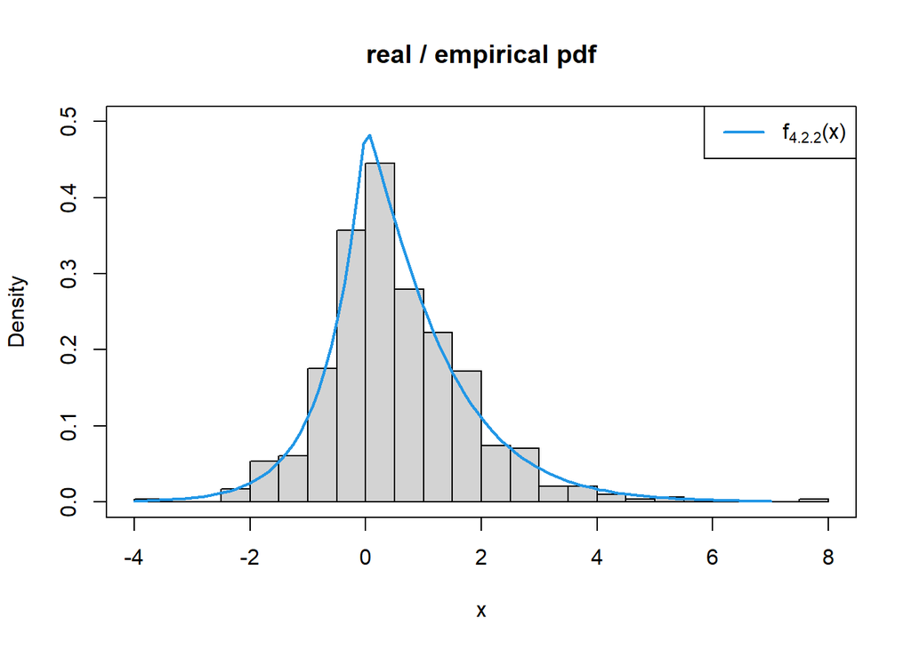

Finally, compute the empirical efficiency $=\ 59.3\%$

## (5) 2-dimension distribution

The target pdf :
$$f(x,y)\ =\ 2(1-x)(1-y)(1-xy)^{-3}\ ,\ 0<x<1\ ,\ 0<y<1$$

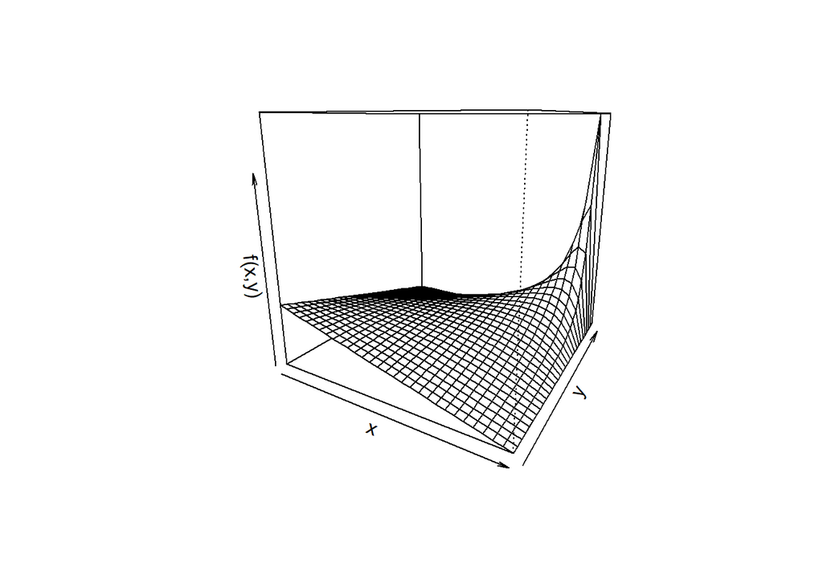

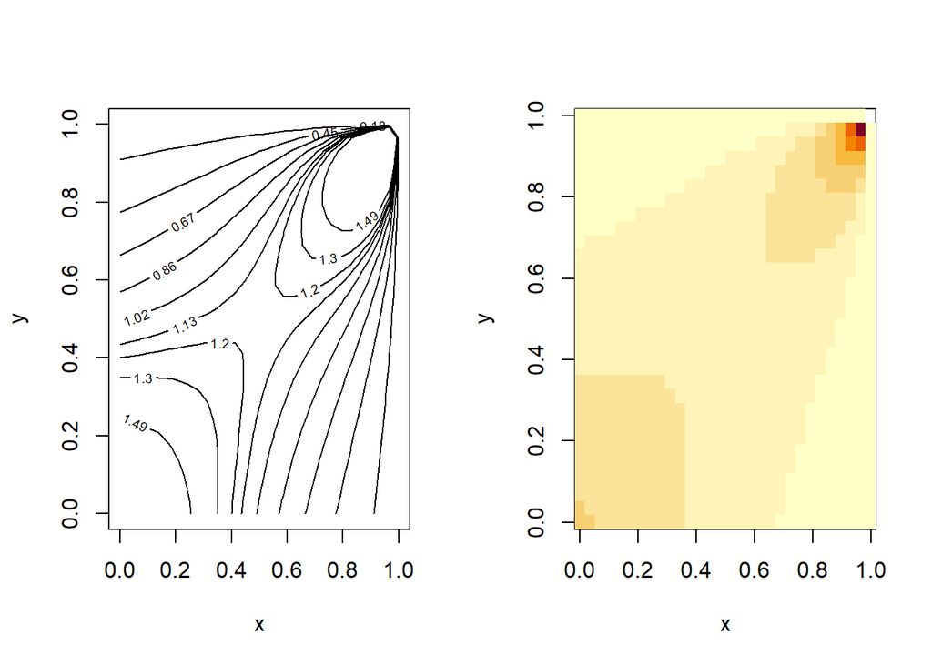

我們可以發現 *f(x,y)* 有以下特徵：  
1. 圖形對稱於 *y=x*  
2. *(x,y)* 皆偏小和皆偏大處 *pdf* 數值較高，特別是偏大處(即圖形右上角)

Let
$$\left\{
\begin{aligned}
u\ =\ log\frac{x}{1-x}\\
v\ =\ log\frac{y}{1-y}
\end{aligned}
\right.\
\Rightarrow\
\left\{
\begin{aligned}
x\ =\ \frac{e^u}{1+e^u}\\
y\ =\ \frac{e^v}{1+e^v}
\end{aligned}
\right.$$
And then transform the target pdf into
$$g(u,v)\ =\ f(\frac{e^u}{1+e^u}\ ,\ \frac{e^v}{1+e^v})|J|\ =\ \frac{2e^ue^v}{(1+e^u+e^v)^3}\ ,\ u\in R\ ,\ v\in R$$
Compute the marginal pdf, marginal cdf and joint cdf of *g(u,v)*
$$\left\{
\begin{aligned}
&g_1(u)\ =\ e^u(1+e^u)^{-2}\ \ and\ \ G_1(u)\ =\ 1-(1+e^u)^{-1}\ ,\ u\in R\\
&g_2(v)\ =\ e^v(1+e^v)^{-2}\ \ and\ \ G_2(v)\ =\ 1-(1+e^v)^{-1}\ ,\ v\in R\\
&G(u,v)\ =\ (1+e^u+e^v)^{-1}\ \ ,\ \ u\in R\ ,\ v\in R
\end{aligned}
\right.$$
$$\Rightarrow\
\left\{
\begin{aligned}
G_1(U)\ \overset{d}{=}\ A\ \sim\ U(0,1)\\
G_2(V)\ \overset{d}{=}\ B\ \sim\ U(0,1)
\end{aligned}
\right.$$
By *Sklar’s Theorem* :
$$\begin{aligned}
G(u,v)\ &=\ P(U\leq u\ ,\ V\leq v)\ =\ P(G_1(U)\leq G_1(u)\ ,\ G_2(V)\leq G_2(v))\ =\ P(G_1(U)\leq a\ ,\ G_2(V)\leq b)\\
&=\ C(a\ ,\ b)\ =\ (1+\frac{a}{1-a}+\frac{b}{1-b})^{-1}\ ,\ 0<a<1\ ,\ 0<b<1
\end{aligned}$$
And
$$c(a\ ,\ b)\ =\ \frac{\partial^2C}{\partial a\partial b}\ =\ 2(1-a)(1-b)(1-ab)^{-3}\ (\text{The same form as }f(x,y))$$
which is the joint pdf of *a* and *b*, where $A\ \sim\ U(0,1)$ and $B|A=a^*\ \sim\ f_{B|A=a^*}(b)\ =\ 2(1-a^*)(1-b)(1-a^*b)^{-3\ ,\ 0<b<1}$

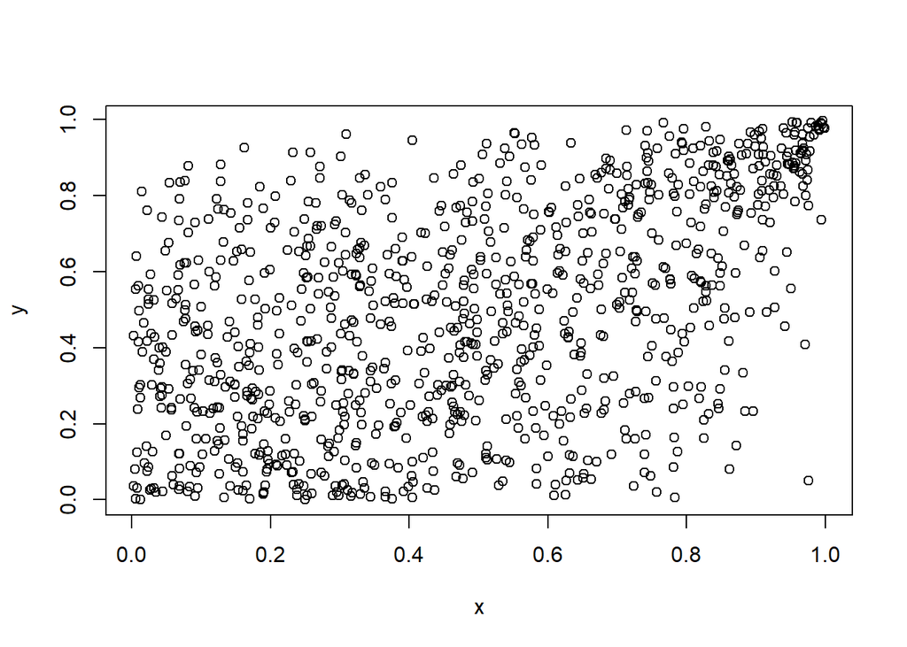

*(x,y)* 的散佈圖看起來右上及左下資料點較為集中，以下繪製二維的 density plot 較為容易觀察

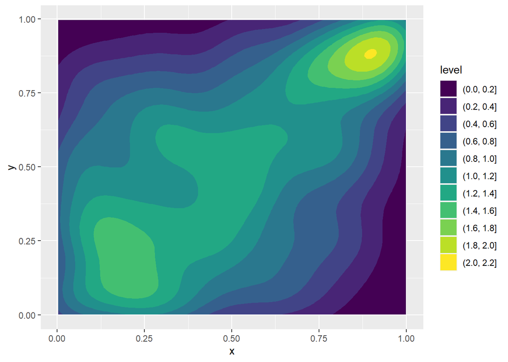

可以觀察到抽出的樣本在二維空間的分布和 target pdf 有許多特徵相似：右上和左下數據較為集中且以右上最多，圖形對稱於*y=x*

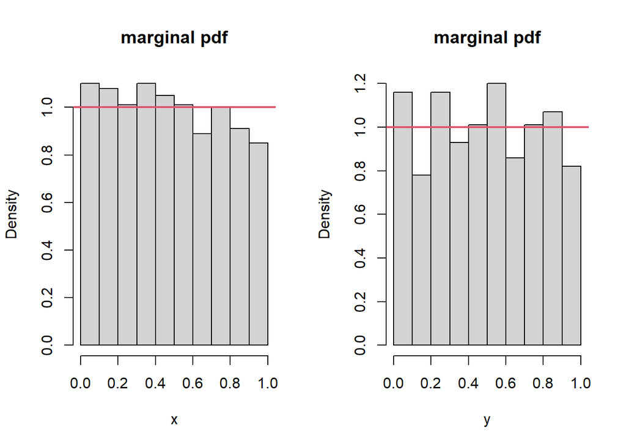

*x* 和 *y* 的 marginal empirical pdf 和 *U(0,1)* 相當接近，也符合 *f(x,y)* 是一個 *copula pdf* 的特性。